# P8105 Final Project

## Data Import

```r
ghed_df <-
  read_excel("data/GHED_data.XLSX")
```

### Safiya’s section

**Indicators** Primary health care - phc_usd_pc  
Infectious disease - dis1_usd2019  
Noncommunicable disease - dis4_usd2019  
Preventive care - hc6_usd2019  
Curative care - hc1_usd2019  
GDP - gdp_pc_usd  
CHE - che_pc_usd

**Primary Health Care Spending**

Primary health care spending by income level (USD per capita)

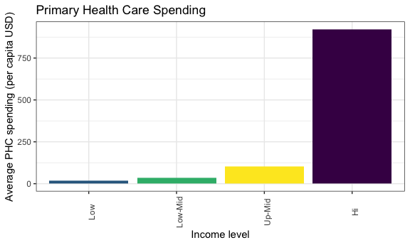

```r
PHC_df <-
  ghed_df %>%
    janitor::clean_names() %>%
    filter(year == 2019) %>%
    drop_na(phc_usd_pc) %>%
    group_by(income_group) %>%
    summarize(
      n_countries = n(),
      avg_phc = mean(phc_usd_pc))

PHC_df %>%
  ggplot(aes(x = fct_relevel(as.factor(income_group), c("Low", "Low-Mid", "Up-Mid", "Hi")), y = avg_phc,  fill = income_group)) +
  geom_col() +
  labs(
    title = "Primary Health Care Spending",
    x = "Income level",
    y = "Average PHC spending (per capita USD)"
  ) +
  theme(axis.text.x = element_text(angle = 90)) +
  theme(legend.position = "none")
```

Primary health care spending by income level (as as proportion of per capita GDP)

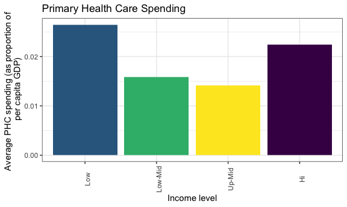

```r
PHC_df <-
  ghed_df %>%
    janitor::clean_names() %>%
    filter(year == 2019) %>%
    drop_na(phc_usd_pc, gdp_pc_usd) %>%
    group_by(income_group) %>%
    summarize(
      n_countries = n(),
      avg_phc = mean(phc_usd_pc / gdp_pc_usd))

PHC_df %>%
  ggplot(aes(x = fct_relevel(as.factor(income_group), c("Low", "Low-Mid", "Up-Mid", "Hi")), y = avg_phc,  fill = income_group)) +
  geom_col() +
  labs(
    title = "Primary Health Care Spending",
    x = "Income level",
    y = "Average PHC spending (as proportion of \n per capita GDP)"
  ) +
  theme(axis.text.x = element_text(angle = 90)) +
  theme(legend.position = "none")
```

Primary health care spending by income level (as a proportion of per capita health expenditure)

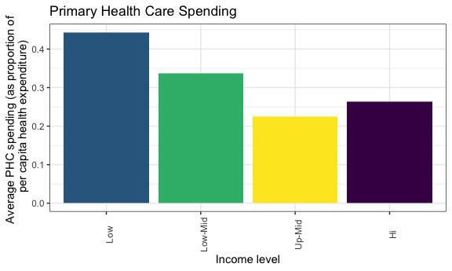

```r
PHC_df <-
  ghed_df %>%
    janitor::clean_names() %>%
    filter(year == 2019) %>%
    drop_na(phc_usd_pc, gdp_pc_usd) %>%
    group_by(income_group) %>%
    summarize(
      n_countries = n(),
      avg_phc = mean(phc_usd_pc / che_pc_usd))

PHC_df %>%
  ggplot(aes(x = fct_relevel(as.factor(income_group), c("Low", "Low-Mid", "Up-Mid", "Hi")), y = avg_phc,  fill = income_group)) +
  geom_col() +
  labs(
    title = "Primary Health Care Spending",
    x = "Income level",
    y = "Average PHC spending (as proportion of \n per capita health expenditure)"
  ) +
  theme(axis.text.x = element_text(angle = 90)) +
  theme(legend.position = "none")
```

**Preventive vs. Curative Spending**

```r
prev_df <-
  ghed_df %>%
    janitor::clean_names() %>%
    filter(year == 2019) %>%
    drop_na(hc6_usd) %>%
    group_by(income_group) %>%
    summarize(
      n_countries = n(),
      `Preventive` = mean(hc6_usd2019))

cur_df <-
  ghed_df %>%
    janitor::clean_names() %>%
    filter(year == 2019) %>%
    drop_na(hc1_usd) %>%
    group_by(income_group) %>%
    summarize(
      n_countries = n(),
      `Curative` = mean(hc1_usd2019))

prev_cur_df <-
  left_join(prev_df, cur_df) %>%
  pivot_longer(
    `Preventive`:`Curative`,
    names_to = "Type of Spending",
    values_to = "avg_spend"
  )
```

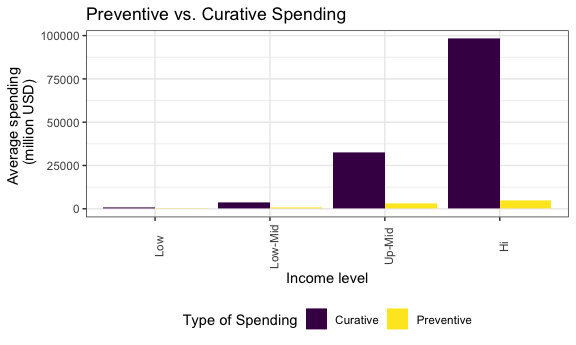

```r
prev_cur_df %>%
  ggplot(aes(x = fct_relevel(as.factor(income_group), c("Low", "Low-Mid", "Up-Mid", "Hi")), y = avg_spend, fill = `Type of Spending`)) +
  geom_bar(stat = "identity", position = "dodge") +
  labs(
    title = "Preventive vs. Curative Spending",
    x = "Income level",
    y = "Average spending \n (million USD)"
  ) +
  theme(axis.text.x = element_text(angle = 90))
```

```r
prev_df <-
  ghed_df %>%
    janitor::clean_names() %>%
    filter(year == 2019) %>%
    drop_na(hc6_usd, gdp_pc_usd) %>%
    group_by(income_group) %>%
    summarize(
      n_countries = n(),
      `Preventive` = mean(hc6_usd2019 / gdp_usd2019))

cur_df <-
  ghed_df %>%
    janitor::clean_names() %>%
    filter(year == 2019) %>%
    drop_na(hc1_usd, gdp_pc_usd) %>%
    group_by(income_group) %>%
    summarize(
      n_countries = n(),
      `Curative` = mean(hc1_usd2019 / gdp_usd2019))

prev_cur_df <-
  left_join(prev_df, cur_df) %>%
  pivot_longer(
    `Preventive`:`Curative`,
    names_to = "Type of Spending",
    values_to = "avg_spend"
  )
```

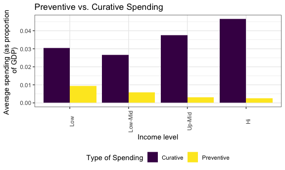

```r
prev_cur_df %>%
  ggplot(aes(x = fct_relevel(as.factor(income_group), c("Low", "Low-Mid", "Up-Mid", "Hi")), y = avg_spend, fill = `Type of Spending`)) +
  geom_bar(stat = "identity", position = "dodge") +
  labs(
    title = "Preventive vs. Curative Spending",
    x = "Income level",
    y = "Average spending (as proportion \n of GDP)"
  ) +
  theme(axis.text.x = element_text(angle = 90))
```

```r
prev_df <-
  ghed_df %>%
    janitor::clean_names() %>%
    filter(year == 2019) %>%
    drop_na(hc6_usd, gdp_pc_usd) %>%
    group_by(income_group) %>%
    summarize(
      n_countries = n(),
      `Preventive` = mean(hc6_usd2019 / che_usd2019))

cur_df <-
  ghed_df %>%
    janitor::clean_names() %>%
    filter(year == 2019) %>%
    drop_na(hc1_usd, gdp_pc_usd) %>%
    group_by(income_group) %>%
    summarize(
      n_countries = n(),
      `Curative` = mean(hc1_usd2019 / che_usd2019))

prev_cur_df <-
  left_join(prev_df, cur_df) %>%
  pivot_longer(
    `Preventive`:`Curative`,
    names_to = "Type of Spending",
    values_to = "avg_spend"
  )
```

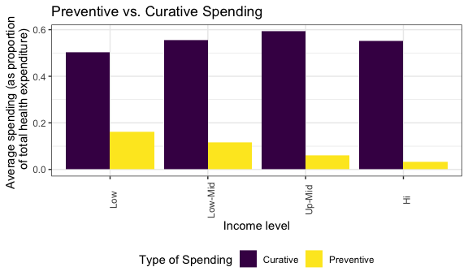

```r
prev_cur_df %>%
  ggplot(aes(x = fct_relevel(as.factor(income_group), c("Low", "Low-Mid", "Up-Mid", "Hi")), y = avg_spend, fill = `Type of Spending`)) +
  geom_bar(stat = "identity", position = "dodge") +
  labs(
    title = "Preventive vs. Curative Spending",
    x = "Income level",
    y = "Average spending (as proportion \n of total health expenditure)"
  ) +
  theme(axis.text.x = element_text(angle = 90))
```

### Ragyie’s section

**Indicators for analysis**

- Curative care, in million constant (2019) US$ —> hc1_usd2019
- Preventive care, in million constant (2019) US$ —> hc6_usd2019
- Infectious and Parasitic Diseases, in million constant (2019) US$ —> dis1_usd2019
- Noncommunicable Diseases (NCDs), in million constant (2019) US$ —> dis4_usd2019
- Primary Health Care (PHC) Expenditure per Capita in US$ —> phc_usd_pc
- GDP - gdp_pc_usd
- CHE - che_pc_usd
- che_usd2019
- gdp_usd2019

**Expenditure category analysis: WHO regions**

Will compare and plot the average in 2019 of spending in categories of interest for each WHO region

**Primary health care**:

```r
phc_ghed =
  ghed_df %>%
  janitor::clean_names() %>%
  filter(year == 2019) %>%
  drop_na(phc_usd_pc) %>%
  group_by(region_who) %>%
  summarize(
    n_countries = n(),
    avg_primary = mean(phc_usd_pc)
  )
```

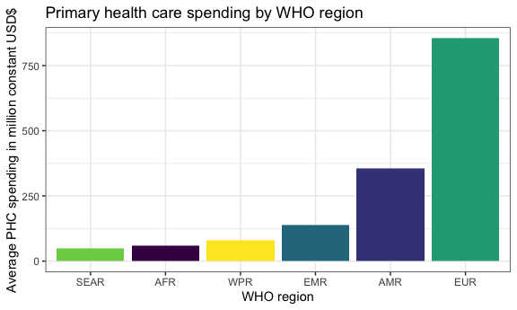

```r
phc_ghed %>%
  ggplot(aes(x = reorder(region_who, avg_primary), y = avg_primary, fill = region_who)) +
  geom_bar(stat = "Identity") +
  labs(
    title = "Primary health care spending by WHO region",
    x = "WHO region",
    y = "Average PHC spending in million constant USD$"
  ) +
  theme(legend.position = "none")
```

Average primary health care expenditure for each WHO region with spending as a percent of GDP

To see how much different WHO regions are spending with regards to what resources they actually have

```r
phc_gdp_ghed =
  ghed_df %>%
  janitor::clean_names() %>%
  filter(year == 2019) %>%
  drop_na(phc_usd_pc, gdp_pc_usd) %>%
  group_by(region_who) %>%
  summarize(
    n_countries = n(),
    avg_primary_gdp = mean(phc_usd_pc / gdp_pc_usd)
  )
```

Barplot: Primary health care expenditure with spending as a percent of GDP

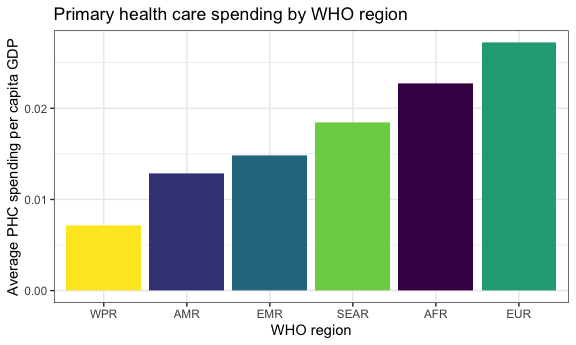

```r
phc_gdp_ghed %>%
  ggplot(aes(x = reorder(region_who, avg_primary_gdp), y = avg_primary_gdp, fill = region_who)) +
  geom_bar(stat = "Identity") +
  labs(
    title = "Primary health care spending by WHO region",
    x = "WHO region",
    y = "Average PHC spending per capita GDP"
  ) +
  theme(legend.position = "none")
```

Average primary health care expenditure for each WHO region with spending as a percentage of current health expenditure

To investigate how much of health spending goes toward each category for each WHO region

```r
phc_che_ghed =
  ghed_df %>%
  janitor::clean_names() %>%
  filter(year == 2019) %>%
  drop_na(phc_usd_pc, che_pc_usd) %>%
  group_by(region_who) %>%
  summarize(
    n_countries = n(),
    avg_primary_che = mean(phc_usd_pc / che_pc_usd)
  )
```

Barplot: Primary health care expenditure with spending as a percent of current health expenditure

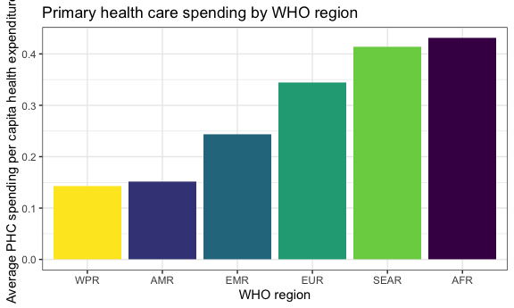

```r
phc_che_ghed %>%
  ggplot(aes(x = reorder(region_who, avg_primary_che), y = avg_primary_che, fill = region_who)) +
  geom_bar(stat = "Identity") +
  labs(
    title = "Primary health care spending by WHO region",
    x = "WHO region",
    y = "Average PHC spending per capita health expenditure"
  ) +
  theme(legend.position = "none")
```

**Curative care vs. preventative care**

Comparing average curative expenditure and average preventative expenditure for each WHO region

Average curative and preventative health care expenditure for each WHO region in million constant USD$

```r
cp_df =
  ghed_df %>%
  janitor::clean_names() %>%
  filter(year == 2019) %>%
  drop_na(hc1_usd2019, hc6_usd2019) %>%
  group_by(region_who) %>%
  summarize(
    n_countries = n(),
    `Curative` = mean(hc1_usd2019),
    `Preventative` = mean(hc6_usd2019)
  ) %>%
  pivot_longer(
    `Curative`:`Preventative`,
    names_to = "spending_type",
    values_to = "average_spending"
  )
```

Barplot: Average curative vs. preventative health care expenditure for each WHO region in million constant USD$

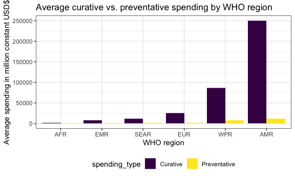

```r
cp_df %>%
  ggplot(aes(x = reorder(region_who, average_spending), y = average_spending, fill = spending_type)) +
  geom_bar(stat = "Identity", position = "Dodge") +
  labs(
    title = "Average curative vs. preventative spending by WHO region",
    x = "WHO region",
    y = "Average spending in million constant USD$"
  )
```

Average curative vs. preventative expenditure for each WHO region with spending as a percent of GDP

```r
cp_gdp_df =
  ghed_df %>%
  janitor::clean_names() %>%
  filter(year == 2019) %>%
  drop_na(hc1_usd2019, hc6_usd2019, gdp_usd2019) %>%
  group_by(region_who) %>%
  summarize(
    n_countries = n(),
    `Curative` = mean(hc1_usd2019 / gdp_usd2019),
    `Preventative` = mean(hc6_usd2019 / gdp_usd2019)
  ) %>%
  pivot_longer(
    `Curative`:`Preventative`,
    names_to = "spending_type",
    values_to = "average_spending"
  )
```

Barplot: Curative vs. preventative expenditure with spending as a percent of GDP

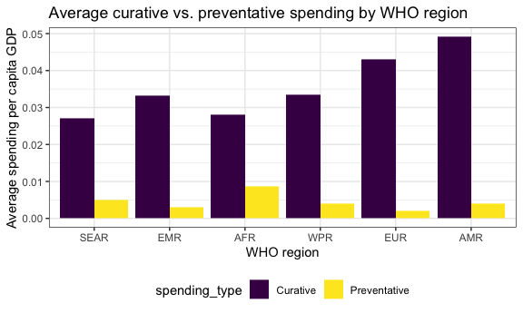

```r
cp_gdp_df %>%
  ggplot(aes(x = reorder(region_who, average_spending), y = average_spending, fill = spending_type)) +
  geom_bar(stat = "Identity", position = "Dodge") +
  labs(
    title = "Average curative vs. preventative spending by WHO region",
    x = "WHO region",
    y = "Average spending per capita GDP"
  )
```

Average curative vs. preventative expenditure for each WHO region with spending as a percentage of current health expenditure

```r
cp_che_df =
  ghed_df %>%
  janitor::clean_names() %>%
  filter(year == 2019) %>%
  drop_na(hc1_usd2019, hc6_usd2019, che_usd2019) %>%
  group_by(region_who) %>%
  summarize(
    n_countries = n(),
    `Curative` = mean(hc1_usd2019 / che_usd2019),
    `Preventative` = mean(hc6_usd2019 / che_usd2019)
  ) %>%
  pivot_longer(
    `Curative`:`Preventative`,
    names_to = "spending_type",
    values_to = "average_spending"
  )
```

Barplot: Curative vs. preventative expenditure with spending as a percent of current health expenditure

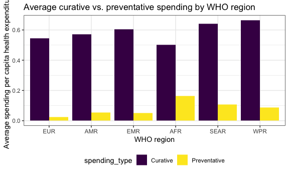

```r
cp_che_df %>%
  ggplot(aes(x = reorder(region_who, average_spending), y = average_spending, fill = spending_type)) +
  geom_bar(stat = "Identity", position = "Dodge") +
  labs(
    title = "Average curative vs. preventative spending by WHO region",
    x = "WHO region",
    y = "Average spending per capita health expenditure"
  )
```

Combining our plots using patchwork to display on website

**Primary health care expenditure **

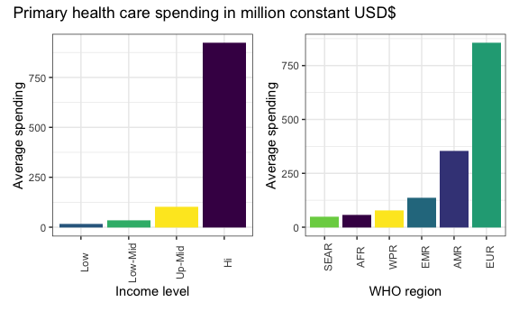

```r
PHC_df <-
  ghed_df %>%
    janitor::clean_names() %>%
    filter(year == 2019) %>%
    drop_na(phc_usd_pc) %>%
    group_by(income_group) %>%
    summarize(
      n_countries = n(),
      avg_phc = mean(phc_usd_pc))

income_constant =
  PHC_df %>%
  ggplot(aes(x = fct_relevel(as.factor(income_group), c("Low", "Low-Mid", "Up-Mid", "Hi")), y = avg_phc,  fill = income_group)) +
  geom_col() +
  labs(
    x = "Income level",
    y = "Average spending"
  ) +
  theme(axis.text.x = element_text(angle = 90)) +
  theme(legend.position = "none")

phc_ghed =
  ghed_df %>%
  janitor::clean_names() %>%
  filter(year == 2019) %>%
  drop_na(phc_usd_pc) %>%
  group_by(region_who) %>%
  summarize(
    n_countries = n(),
    avg_primary = mean(phc_usd_pc)
  )

region_constant =
  phc_ghed %>%
  ggplot(aes(x = reorder(region_who, avg_primary), y = avg_primary, fill = region_who)) +
  geom_bar(stat = "Identity") +
  labs(
    x = "WHO region",
    y = "Average spending"
  ) +
  theme(axis.text.x = element_text(angle = 90)) +
  theme(legend.position = "none")

combined_constant = income_constant + region_constant

combined_constant +
  plot_annotation(
    title = "Primary health care spending in million constant USD$"
  )
```

per capita GDP

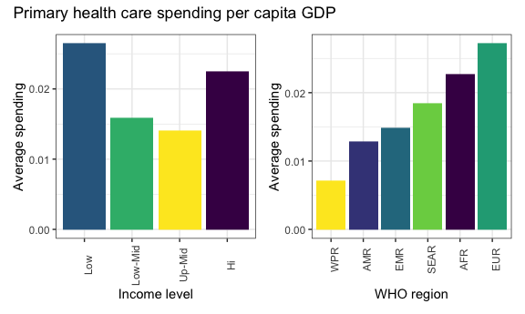

```r
PHC_df =
  ghed_df %>%
  janitor::clean_names() %>%
  filter(year == 2019) %>%
  drop_na(phc_usd_pc, gdp_pc_usd) %>%
  group_by(income_group) %>%
  summarize(
    n_countries = n(),
    avg_phc = mean(phc_usd_pc / gdp_pc_usd))

income_gdp =
  PHC_df %>%
  ggplot(aes(x = fct_relevel(as.factor(income_group), c("Low", "Low-Mid", "Up-Mid", "Hi")), y = avg_phc,  fill = income_group)) +
  geom_col() +
  labs(
    x = "Income level",
    y = "Average spending"
  ) +
  theme(axis.text.x = element_text(angle = 90)) +
  theme(legend.position = "none")

phc_gdp_ghed =
  ghed_df %>%
  janitor::clean_names() %>%
  filter(year == 2019) %>%
  drop_na(phc_usd_pc, gdp_pc_usd) %>%
  group_by(region_who) %>%
  summarize(
    n_countries = n(),
    avg_primary_gdp = mean(phc_usd_pc / gdp_pc_usd)
  )

region_gdp =
  phc_gdp_ghed %>%
  ggplot(aes(x = reorder(region_who, avg_primary_gdp), y = avg_primary_gdp, fill = region_who)) +
  geom_bar(stat = "Identity") +
  labs(
    x = "WHO region",
    y = "Average spending"
  ) +
  theme(axis.text.x = element_text(angle = 90)) +
  theme(legend.position = "none")

combined_gdp = income_gdp + region_gdp

combined_gdp +
  plot_annotation(
    title = "Primary health care spending per capita GDP"
  )
```

per capita current health expenditure

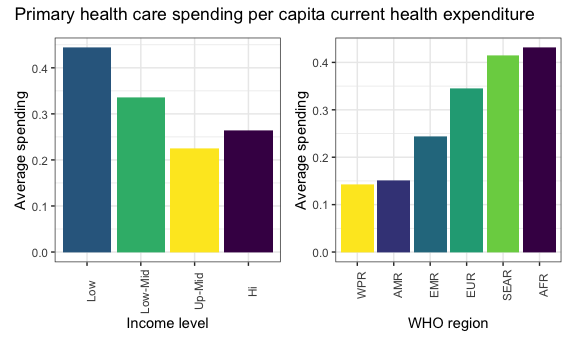

```r
PHC_df =
  ghed_df %>%
  janitor::clean_names() %>%
  filter(year == 2019) %>%
  drop_na(phc_usd_pc, che_pc_usd) %>%
  group_by(income_group) %>%
  summarize(
    n_countries = n(),
    avg_phc = mean(phc_usd_pc / che_pc_usd))

income_che =
  PHC_df %>%
  ggplot(aes(x = fct_relevel(as.factor(income_group), c("Low", "Low-Mid", "Up-Mid", "Hi")), y = avg_phc,  fill = income_group)) +
  geom_col() +
  labs(
    x = "Income level",
    y = "Average spending"
  ) +
  theme(axis.text.x = element_text(angle = 90)) +
  theme(legend.position = "none")

phc_che_ghed =
  ghed_df %>%
  janitor::clean_names() %>%
  filter(year == 2019) %>%
  drop_na(phc_usd_pc, che_pc_usd) %>%
  group_by(region_who) %>%
  summarize(
    n_countries = n(),
    avg_primary_che = mean(phc_usd_pc / che_pc_usd)
  )

region_che =
  phc_che_ghed %>%
  ggplot(aes(x = reorder(region_who, avg_primary_che), y = avg_primary_che, fill = region_who)) +
  geom_bar(stat = "Identity") +
  labs(
    x = "WHO region",
    y = "Average spending"
  ) +
  theme(axis.text.x = element_text(angle = 90)) +
  theme(legend.position = "none")

combined_che = income_che + region_che

combined_che +
  plot_annotation(
    title = "Primary health care spending per capita current health expenditure"
  )
```

### Trisha’s section

```r
ghed_df =
  ghed_df %>%
  janitor::clean_names()
```

## Distribution of income levels of countries in each WHO region

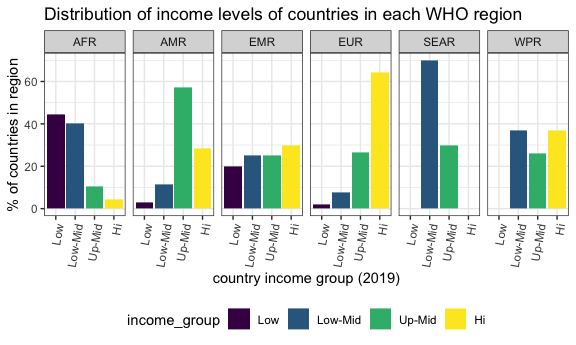

```r
ghed_df %>%
  select(country, country_code, region_who, income_group) %>%
  distinct() %>%
  mutate(
    income_group = as.factor(income_group),
    income_group = factor(income_group, levels = c("Low","Low-Mid","Up-Mid","Hi"))
  ) %>%
  group_by(region_who) %>%
  mutate(
    num_countries = n()
  ) %>%
  group_by(region_who, income_group, num_countries) %>%
  summarize(n = n()) %>%
  mutate(
    perc_income_group = 100*(n/num_countries)
  ) %>%
  ggplot(aes(x=income_group,y=perc_income_group)) +
  geom_bar(aes(fill=income_group),stat="identity") +
  facet_grid(~region_who) +
  theme(axis.text.x = element_text(angle = 80, hjust = 1)) +
  ggtitle("Distribution of income levels of countries in each WHO region") +
  ylab("% of countries in region") +
  xlab("country income group (2019)")
```

The figure above shows the distribution of income levels of countries (categorized in 2019) in each WHO region: AFR (African Region), AMR (Region of the Americas), EMR (Eastern Mediterranean Region), EUR (European Region), SEAR (South-East Asian Region), and WPR (Western Pacific Region).

Highest proportion of income group type by region:  
Low income: AFR  
Low-Mid income: SEAR  
Up-Mid income: AMR  
Hi income: EUR

## Income group and total healthcare expenditure

```r
ghed_df %>%
  select(country, country_code, region_who, income_group, year, che_gdp, che_pc_usd) %>%
  filter(year == 2019) %>%
  mutate(
    income_group= as.factor(income_group),
    income_group = factor(income_group, levels = c("Low","Low-Mid","Up-Mid","Hi"))
  ) %>%
  group_by(income_group) %>%
  summarise(mean_che_gdp = mean(che_gdp,na.rm=TRUE), mean_che_pc_usd = mean(che_pc_usd,na.rm=TRUE)) %>%
  rename("Mean Current Health Expenditure as % of GDP"="mean_che_gdp") %>%
  rename("Mean Current Health Expenditure per Capita (US$)"="mean_che_pc_usd") %>%
  knitr::kable(digits = 2)
```

| income_group | Mean Current Health Expenditure as % of GDP | Mean Current Health Expenditure per Capita (US$) |
| --- | --- | --- |
| Low | 6.01 | 39.25 |
| Low-Mid | 5.08 | 126.69 |
| Up-Mid | 6.90 | 482.74 |
| Hi | 7.69 | 2937.29 |

### WHO region and total healthcare expenditure

```r
ghed_df %>%
  select(country, country_code, region_who, income_group, year, che_gdp, che_pc_usd) %>%
  filter(year == 2019) %>%
  group_by(region_who) %>%
  summarise(mean_che_gdp = mean(che_gdp,na.rm=TRUE), mean_che_pc_usd = mean(che_pc_usd,na.rm=TRUE)) %>%
  arrange(mean_che_pc_usd) %>%
  rename("Mean Current Health Expenditure as % of GDP"="mean_che_gdp") %>%
  rename("Mean Current Health Expenditure per Capita (US$)"="mean_che_pc_usd") %>%
  knitr::kable(digits = 2)
```

[output not shown]

The major developed economies we take a closer look at are known as the G-7 countries and comprise of countries with the world’s largest developed economies: Canada, Japan, France, Germany, Italy, United Kingdom, and the United States of America.

```r
# total_spending_developed_plot =
#   ghed_df %>%
#   select(country, country_code, region_who, income_group, year, che_gdp, che_pc_usd) %>%
#   filter(country == "United States of America" |
#          country == "United Kingdom" |
#          country == "Italy" |
#          country == "Germany" |
#          country == "France" |
#          country == "Japan" |
#          country == "Canada") %>%
#   mutate(
#     year = as.numeric(year)
#   ) %>%
#   group_by(country) %>%
#   plot_ly(x = ~year) %>%
#   add_trace(y = ~che_pc_usd, name = ~country, mode = 'lines+markers') %>%
#   layout(title = 'Total spending over time in developed countries (per capita)', yaxis = list(title = 'Total Health Expenditure (US$)'), showlegend=FALSE)

#
#   ggplot(aes(x=year,y=che_pc_usd, color=country),show.legend = FALSE) +
#   geom_line(show.legend = FALSE) +
#   geom_point(show.legend = FALSE) +
#   ggtitle("Total spending over time in developed countries (per capita)") +
#   ylab("Total Health Expenditure (US$)") +
#   scale_colour_viridis_d()
```

```r
# govt_spending_developed_plot =
#   ghed_df %>%
#   select(country, country_code, region_who, income_group, year, gghed_pc_usd) %>%
#   filter(country == "United States of America" |
#          country == "United Kingdom" |
#          country == "Italy" |
#          country == "Germany" |
#          country == "France" |
#          country == "Japan" |
#          country == "Canada") %>%
#   mutate(
#     year = as.numeric(year)
#   ) %>%
#   group_by(country) %>%
#   plot_ly(x = ~year) %>%
#   add_trace(y = ~gghed_pc_usd, name = ~country, mode = 'lines+markers') %>%
#   layout(title = 'Government spending over time in developed countries (per capita)', yaxis = list(title = 'Government Health Expenditure (US$)'), legend = list(orientation = 'h'))
#
  # ggplot(aes(x=year,y=gghed_pc_usd, color=country)) +
  # geom_line() +
  # geom_point() +
  # ggtitle("Government spending over time in developed countries (per capita)") +
  # ylab("Government Health Expenditure (US$)") +
  # scale_colour_viridis_d()
```

```r
# total_spending_developed_plot
# govt_spending_developed_plot
```

## Developing countries - total spending over time

The developing economies we dive into are from a list of countries with developing economies by region in the Country classification document from the UN website: Morocco, Uganda, South Africa, Senegal, Nepal, Iraq, Haiti, Mexico, and Argentina.

```r
total_spending_developing_plot =
  ghed_df %>%
  select(country, country_code, region_who, income_group, year, che_gdp, che_pc_usd) %>%
  filter(country == "Morocco" |
         country == "Uganda" |
         country == "South Africa" |
         country == "Senegal" |
         country == "Nepal" |
         country == "Iraq" |
         country == "Haiti" |
         country == "Mexico" |
         country == "Argentina") %>%
  mutate(
    year = as.numeric(year)
  ) %>%
  group_by(country) %>%
  ggplot(aes(x=year,y=che_pc_usd, color=country),show.legend = FALSE) +
  geom_line(show.legend = FALSE) +
  geom_point(show.legend = FALSE) +
  ggtitle("Total spending over time in developing countries (per capita)") +
  ylab("Total Health Expenditure (US$)") +
  scale_colour_viridis_d()
```

```r
govt_spending_developing_plot =
  ghed_df %>%
  select(country, country_code, region_who, income_group, year, gghed_pc_usd) %>%
  filter(country == "Morocco" |
         country == "Uganda" |
         country == "South Africa" |
         country == "Senegal" |
         country == "Nepal" |
         country == "Iraq" |
         country == "Haiti" |
         country == "Mexico" |
         country == "Argentina") %>%
  mutate(
    year = as.numeric(year)
  ) %>%
  group_by(country) %>%
  ggplot(aes(x=year,y=gghed_pc_usd, color=country)) +
  geom_line() +
  geom_point() +
  ggtitle("Government spending over time in developing countries (per capita)") +
  ylab("Government Health Expenditure (US$)") +
  scale_colour_viridis_d()
```

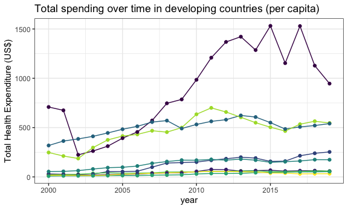

```r
total_spending_developing_plot
```

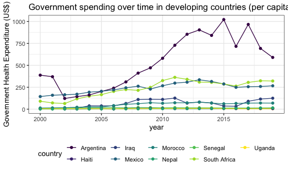

```r
govt_spending_developing_plot
```

## LM - correlation between WHO region, external funding, private spending, and government expenditure and income group

```r
ghed_lm_df =
  ghed_df %>%
  select(country, country_code, region_who, income_group, ext_pc_usd, pvtd_pc_usd, gghed_pc_usd) %>%
  drop_na() %>%
  mutate(
    income_group = as.factor(income_group),
    income_group = factor(income_group, levels = c("Low","Low-Mid","Up-Mid","Hi")),
    income_group = fct_recode(income_group, '1'="Low",'2'="Low-Mid", '3'="Up-Mid", '4'="Hi")
  )
```

```r
ghed_lm_df_shuffled = ghed_lm_df[sample(nrow(ghed_lm_df)),]

ghed_lm_df_shuffled =
  ghed_lm_df_shuffled %>%
  mutate(
    sum_pc = ext_pc_usd + pvtd_pc_usd + gghed_pc_usd,
    ext_pc_usd = ext_pc_usd/sum_pc,
    pvtd_pc_usd = pvtd_pc_usd/sum_pc,
    gghed_pc_usd = gghed_pc_usd/sum_pc
  )
```

```r
fit_exp_dstbn = lm(as.numeric(income_group) ~ ext_pc_usd + pvtd_pc_usd + gghed_pc_usd, ghed_lm_df_shuffled)
fit_region_exp = lm(as.numeric(income_group) ~ ext_pc_usd + pvtd_pc_usd + gghed_pc_usd + region_who, ghed_lm_df_shuffled)

summary(fit_exp_dstbn)
```

```
##
## Call:
## lm(formula = as.numeric(income_group) ~ ext_pc_usd + pvtd_pc_usd +
##     gghed_pc_usd, data = ghed_lm_df_shuffled)
##
## Residuals:
##      Min       1Q   Median       3Q      Max
## -2.06118 -0.48440  0.04227  0.47417  2.31487
##
## Coefficients: (1 not defined because of singularities)
##              Estimate Std. Error t value Pr(>|t|)
## (Intercept)   4.14131    0.03250  127.44   <2e-16 ***
## ext_pc_usd   -4.59240    0.08648  -53.10   <2e-16 ***
## pvtd_pc_usd  -2.41383    0.06394  -37.75   <2e-16 ***
## gghed_pc_usd       NA         NA      NA       NA
## ---
## Signif. codes:  0 '***' 0.001 '**' 0.01 '*' 0.05 '.' 0.1 ' ' 1
##
## Residual standard error: 0.7228 on 3337 degrees of freedom
## Multiple R-squared:  0.5112, Adjusted R-squared:  0.5109
## F-statistic:  1745 on 2 and 3337 DF,  p-value: < 2.2e-16
```

```r
fit_region_exp %>%
  broom::glance()
```

```
## # A tibble: 1 × 12
##   r.squared adj.r.squared sigma statistic p.value    df logLik   AIC   BIC
##       <dbl>         <dbl> <dbl>     <dbl>   <dbl> <dbl>  <dbl> <dbl> <dbl>
## 1     0.585         0.585 0.666      672.       0     7 -3378. 6775. 6830.
## # … with 3 more variables: deviance <dbl>, df.residual <int>, nobs <int>
```

### Pooja’s Part

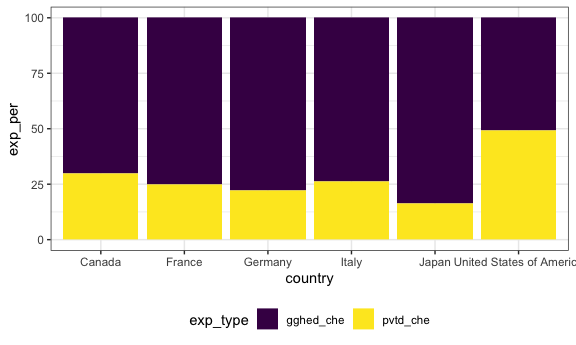

```r
#Developed - Canada, Japan, France, Germany, Italy, UK, US

ghed_df%>%
  filter(country=="Canada"| country=="Japan"| country=="France"| country=="Germany"| country=="Italy"| country=="United Kingdom
"| country=="United States of America")%>%
  filter(year == 2019)%>%
  select(country, year, gghed_che, pvtd_che)%>%
  mutate(sum_per = gghed_che + pvtd_che)%>%
  pivot_longer(cols = contains("che"),
               names_to = "exp_type",
               values_to = "exp_per")%>%
  ggplot(aes(fill = exp_type, y = exp_per, x = country))+
  geom_bar(position="stack", stat="identity")
```

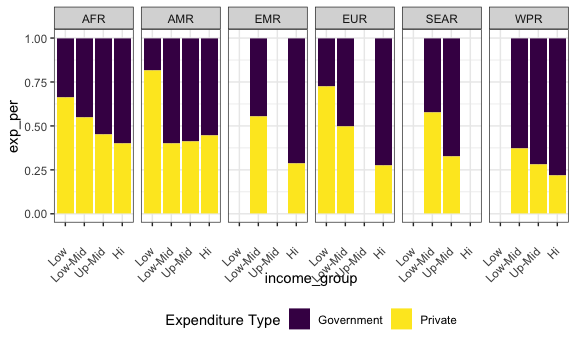

```r
ghed_df%>%
  filter(year == 2019)%>%
  select(region_who, income_group, year, gghed_che, pvtd_che)%>%
  group_by(region_who, income_group)%>%
  mutate(sum_gghed = sum(gghed_che),
         sum_pvtd = sum(pvtd_che),
         sum_che = sum_gghed + sum_pvtd,
         income_group = factor(income_group, levels = c("Low", "Low-Mid", "Up-Mid", "Hi")))%>%
  select(region_who, income_group, year, sum_gghed, sum_pvtd, sum_che)%>%
  distinct()%>%
  mutate(gghed_per = sum_gghed/sum_che,
         pvtd_per = sum_pvtd/sum_che)%>%
  pivot_longer(cols = contains("per"),
               names_to = "exp_type",
               values_to = "exp_per")%>%
  select(region_who, income_group, exp_type, exp_per)%>%
  ggplot(aes(fill = exp_type, y = exp_per, x = income_group))+
  geom_bar(stat="identity")+facet_grid(cols = vars(region_who))+theme(axis.text.x = element_text(angle = 45, vjust = 0.5, hjust=1))+
scale_fill_discrete(name="Expenditure Type",
                         breaks=c("gghed_per", "pvtd_per"),
                         labels=c("Government", "Private"))
```

Government vs. Private expenditure over time in the US

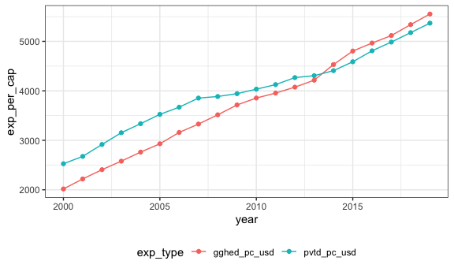

```r
ghed_df%>%
  filter(country == "United States of America")%>%
  select(country, year, gghed_pc_usd, pvtd_pc_usd)%>%
  pivot_longer(cols = contains("pc_usd"),
               names_to = "exp_type",
               values_to = "exp_per_cap")%>%
  ggplot() + geom_point(aes(x = year, y = exp_per_cap, col = exp_type))+geom_line(aes(x = year, y = exp_per_cap, group = exp_type, colour = exp_type))
```

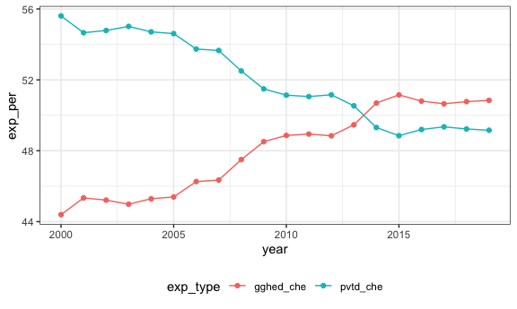

```r
ghed_df%>%
  filter(country=="United States of America")%>%
  select(country, year, gghed_che, pvtd_che)%>%
  mutate(sum_per = gghed_che + pvtd_che)%>%
  pivot_longer(cols = contains("che"),
               names_to = "exp_type",
               values_to = "exp_per")%>%
  ggplot() + geom_point(aes(x = year, y = exp_per, col = exp_type))+geom_line(aes(x = year, y = exp_per, group = exp_type, colour = exp_type))
```

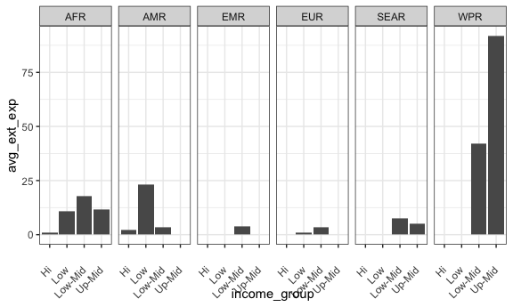

```r
ghed_df%>%
  filter(year ==2019)%>%
  select(country,region_who, year,income_group, gghed_pc_usd, pvtd_pc_usd, ext_pc_usd)%>%
  group_by(region_who, income_group)%>%
  mutate(avg_ext_exp = mean(ext_pc_usd))%>%
  select(region_who, income_group, avg_ext_exp)%>%
  distinct()%>%
    ggplot(aes(y = avg_ext_exp, x = income_group))+
  geom_bar(stat="identity")+facet_grid(cols = vars(region_who))+theme(axis.text.x = element_text(angle = 45, vjust = 0.5, hjust=1))
```

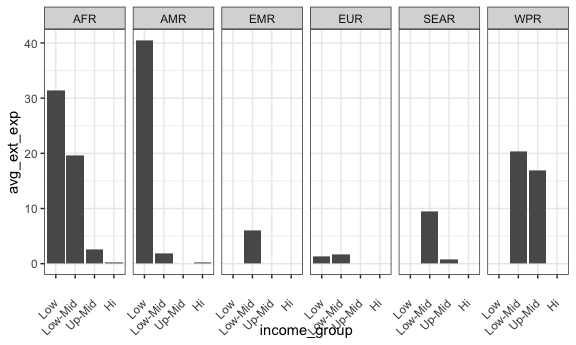

```r
ghed_df%>%
  filter(year ==2019)%>%
  select(country,region_who, year,income_group, gghed_pc_usd, pvtd_pc_usd, ext_che)%>%
  group_by(region_who, income_group)%>%
  mutate(avg_ext_exp = mean(ext_che),
         income_group = factor(income_group, levels = c("Low", "Low-Mid", "Up-Mid", "Hi")))%>%
  select(region_who, income_group, avg_ext_exp)%>%
  distinct()%>%
    ggplot(aes(y = avg_ext_exp, x = income_group))+
  geom_bar(stat="identity")+facet_grid(cols = vars(region_who))+theme(axis.text.x = element_text(angle = 45, vjust = 0.5, hjust=1))
```

```r
un_country_class<- read_csv("data/un_country_classification.csv")
head(un_country_class)
un_country_class<- un_country_class%>%
  janitor::clean_names()%>%
  select(country_or_area, developed_developing_countries)%>%
  mutate(developed = str_replace(developed_developing_countries, ".*Developing.*", "Developing"))%>%
  select(country_or_area, developed)



ghed_df<- left_join(ghed_df, un_country_class, by = c("country" = "country_or_area"))
```

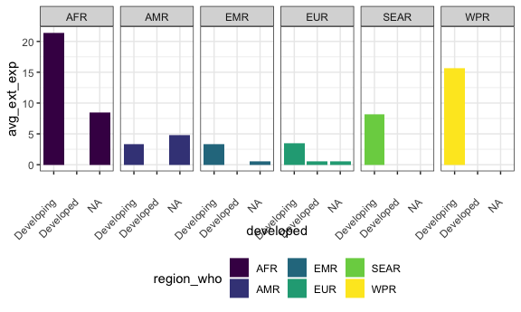

```r
 ghed_df%>%
  select(country,region_who, year,developed, gghed_pc_usd, pvtd_pc_usd, ext_che)%>%
  group_by(region_who, developed)%>%
  mutate(avg_ext_exp = mean(ext_che,na.rm=TRUE),
         developed = factor(developed, levels = c(NA, "Developing", "Developed")))%>%
  select(region_who, developed, avg_ext_exp)%>%
  distinct()%>%
    ggplot(aes(y = avg_ext_exp, x = developed, colours=region_who))+
  geom_bar(stat="identity", aes(fill = region_who))+facet_grid(cols = vars(region_who))+theme(axis.text.x = element_text(angle = 45, vjust = 0.5, hjust=1))+scale_fill_viridis_d()
```